# Estudio predictivo de enfermedades cardíacas

## **Marco Teórico**

### *Objetivo*

Hallar una relación entre la incidencia de enfermedades cardíacas con diversos factores como la edad, sexo y otros factores médicos, teniendo como finalidad la predicción de enfermedades cardiovasculares en pacientes y así poder preverlas.

### *Población*

El conjunto de datos que utilizaremos se creó combinando diferentes conjuntos de datos que ya estaban disponibles de forma independiente, pero que no se habían combinado antes. En este conjunto de datos, se combinan 5 conjuntos de datos cardíacos sobre 11 características comunes, lo que lo convierte en el conjunto de datos de enfermedades cardíacas más grande disponible hasta ahora para fines de investigación. Los cinco conjuntos de datos utilizados para su curación son:

Cleveland: 303 observaciones  
Húngaro: 294 observaciones  
Suiza: 123 observaciones  
Long Beach VA: 200 observaciones  
Conjunto de datos de Stalog (corazón): 270 observaciones

### *Unidades muestrales*

Individuos de diferentes ciudades.

### *Variables*

- Edad
- Sexo
- Tipo de dolor torácico
- Presión arterial en reposo
- Colesterol sérico
- Azúcar en la sangre en ayunas
- Resultados del electrocardiograma en reposo
- frecuencia cardíaca máxima alcanzada
- Angina inducida por el ejercicio

### *Tipos de variables*

Se usaron variables numéricas y categóricas.

### *Introducción*

Las enfermedades cardiovasculares (ECV) son la causa número 1 de muertes en el mundo. Estas provocan alrededor de 18.6 millones de muertes al año. Según la Federación Mundial del Corazón , el 80% de fallecimientos por ECV pudieron haber sido prevenidos.

Estas enfermedades normalmente son altamente prevenibles debido a que son ocasionadas principalmente por el estilo de vida. Por esto, es importante detectar cualquier problema cardiaco desde una etapa temprana para evitar consecuencia fatales. En este estudio estadístico se utilizan diversos factores que pueden ser usados para predecir con antelación una enfermedad cardíaca.[^1]

## **Preguntas introductorias**

#### **¿La mayoría de personas con enfermedades cardíacas son hombres o mujeres? ¿Cuál es su porcentaje?**

Se sabe que el porcentaje de personas del sexo masculino es de 78.97603 % , por lo que es mas posible que quienes mas padezcan de enfermedades cardíacas sean hombres. Apoyándonos es un estudio realizado por Investigadores de Mayo Clinic (Estados Unidos). En el cual, los expertos comprobaron que las mujeres tienen menos ataques cardíacos que los hombres en todos los grupos de edad clasificados en este estudio. En nuestra muestra el 49.891068 % representa el porcentaje de hombres que padecen alguna enfermedad cardíaca.

#### **¿Cuál es la edad en la que se presenta la mayor cantidad de personas con enfermedades cardíacas?**

La muestra contiene personas desde los 28 hasta los 77 años. Según el instituto National Institute on Aging que afirma que los cambios que ocurren con la edad pueden aumentar el riesgo de una persona de desarrollar una enfermedad cardíaca puesto que el envejecimiento puede causar cambios en el corazón y en los vasos sanguíneos. Basándonos en esa información y en que la etapa de envejecimiento empieza desde los 60 años según el instituto nacional de Geriatría se espera que la mayor cantidad de personas con enfermedades cardíacas se ubiquen en el intervalo de 60 a 77 años de edad.

#### **¿La mayor cantidad de personas que no presentan colesterol sérico son hombres o mujeres? ¿Cuál es su porcentaje?**

Se sabe que el porcentaje de personas del sexo masculino es de 78.97603 % , por lo que es mas posible que sean quienes no padecen de colesterol sérico sean hombres. Así mismo, según la Asociación Americana del Corazón (AHA) señalan que el riesgo de colesterol elevado suele aumentar con la edad, y el trastorno es más común en las mujeres que en los hombres.En nuestra muestra se observa que aproximadamente el 17.5381264% de hombres no padecen de colesterol sérico.

#### **¿Existe una relación entre presión arterial en reposo y colesterol sérico?¿De existir, como es esta relación?**

Según Mayo Clinic, el colesterol alto ocasiona la acumulación de colesterol en las paredes arteriales, lo que a su vez es un factor para la hipertensión arterial (presión alta). Por lo que se esperaría ver una relación directamente proporcional entre el colesterol sérico y la presión arterial en reposo.

#### **¿Qué relación guarda el colesterol sérico con los resultados de electrocardiograma en reposo en las personas evaluadas?**

El colesterol sérico en cantidades altas puede tener efectos nocivos en la salud. Según Mayo Clinic, es un factor para los ataques cardíacos. Por esto es posible que veamos una relación en la que en una alza de colesterol sérico (predominando el colesterol malo) corresponda con algún resultado de electrocardiograma ST o HVI, indicando que hay complicaciones cardíacas.

#### **¿Qué tipo de dolor de pecho es predominante?¿Qué porcentaje tiene?¿Hay alguna variable que se relacione con algún tipo de dolor de pecho?**

Hay tipos de dolor de pecho, entre los cuales están los causados por anginas, los no causados por anginas, asintomáticos, etc. Los dolores de pecho pueden ser ocasionados por muchas cosas, y no necesariamente por una angina, por lo que se espera que predomine el dolor de pecho asintomático. Según Mayo Clinic, el colesterol alto afecta a las arterias y el suministro de sangre al corazón, lo que puede ocasionar angina de pecho. Es por eso que esta variable podría aumentar la incidencia de los dolores de pecho ocasionados por anginas.

#### **¿Cuál es la cantidad de personas que padece de enfermedad cardíaca y que tiene azúcar en la sangre en ayunas mayor a 120 mg/dl ?**

Se puede afirmar que son 170 personas, que vendrían a representar el 18.52% del total de la muestra escogida. Si bien no pasa el 50%, se puede apreciar que si hay una población considerable que posee azúcar en la sangre en ayunas mayor a 120 mg/dl y que padece de enfermedad cardíaca, por lo que se podría evidenciar una relación entre ambas variables.

#### **¿Cuál es el porcentaje de personas que tienen presión arterial en reposo mayor a 80 y que a su vez, padecen de enfermedad cardíaca?**

Según el Ministerio de Salud, la presión arterial en reposo no debe superar los 80 mm Hg ya que pasar esa presión sería un indicador de hipertensión. Aproximadamente el 55.22% de personas que tiene presión arterial en reposo mayor a 80 mm Hg padece de enfermedad cardíaca. Esto podría indicar la relación directa que tienen ambas variables ya que ocurre en más de la mitad de la población.[^3]

## **Datos y librerías**

Aquí tenemos las librerías que utilizaremos para el procesamiento de datos. Además está la lectura de la base de datos en un dataframe.

```r
#knitr::opts_chunk$set(echo = FALSE)
#install.packages("modeest")
#install.packages("readr")
#install.packages("tidyverse")
library(readr)
library("modeest")
library("readr")
library("tidyverse")
DF = read.csv("heart.csv")
```

## **Descriptores numéricos y gráficos de las variables**

### **Edad**

```r
maximo=max(DF$Edad)
minimo=min(DF$Edad)
media = mean(unlist(DF$Edad))
mediana = median(DF$Edad)
moda = mfv(DF$Edad)
rango= maximo-minimo
varianza = var(unlist(DF$Edad))
variación_estándar = sd(unlist(DF$Edad))
rango_intercuartil = quantile(unlist(DF$Edad), 0.75)-quantile(unlist(DF$Edad), 0.25)
```

```
## [1] "La edad máxima es: 77"
```

```
## [1] "La edad mínima es: 28"
```

```
## [1] "La media es: 53.5108932461874"
```

```
## [1] "La mediana es: 54"
```

```
## [1] "El rango es: 49"
```

```
## [1] "La varianza es: 88.9742541630732"
```

```
## [1] "La variación estándar  es: 9.43261650673201"
```

```
## [1] "La rango intercuartil  es: 13"
```

```
## [1] "La moda es: 54"
```

```r
#Frecuencia de la edad
tabla_edad = as.data.frame(table(Edad = DF$Edad ))
tablae = transform(tabla_edad,
          FreqAc = cumsum(Freq),
          Rel = round(prop.table(Freq), 3),
          RelAc= round(cumsum(prop.table(Freq)),3))
tablae
```

```
##    Edad Freq FreqAc   Rel RelAc
## 1    28    1      1 0.001 0.001
## 2    29    3      4 0.003 0.004
## 3    30    1      5 0.001 0.005
## 4    31    2      7 0.002 0.008
## 5    32    5     12 0.005 0.013
## 6    33    2     14 0.002 0.015
## 7    34    7     21 0.008 0.023
## 8    35   11     32 0.012 0.035
## 9    36    6     38 0.007 0.041
## 10   37   11     49 0.012 0.053
## 11   38   16     65 0.017 0.071
## 12   39   15     80 0.016 0.087
## 13   40   13     93 0.014 0.101
## 14   41   24    117 0.026 0.127
```

[output cut: 36 more lines]

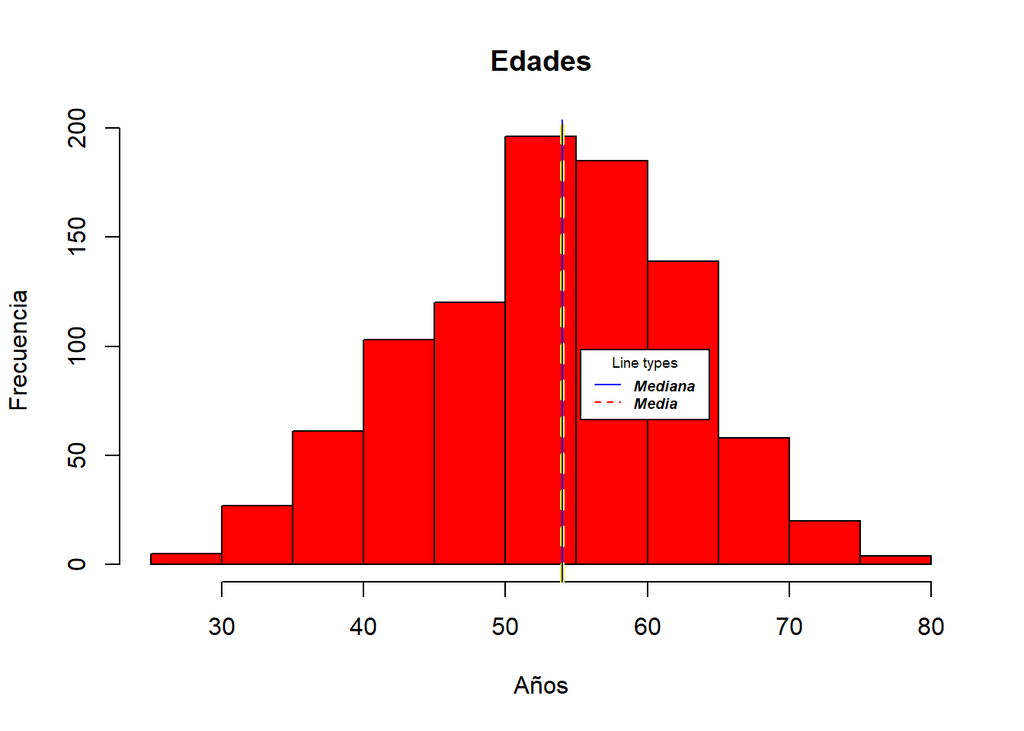

```r
hist(DF$Edad, xlab = "Años", ylab = "Frecuencia"  , col = "red",main = "Edades")
abline(v = median(DF$Edad), col="yellow", lwd=3, lty=2)
abline(v = median(DF$Edad), col="blue")
legend(x="bottomright", inset = c(0.3, 0.35), legend=c("Mediana  ", "Media    "),col=c("blue", "red"),lty=1:2, cex=0.6,
       title="Line types", text.font=4)
```

#### **Diagrama de caja**

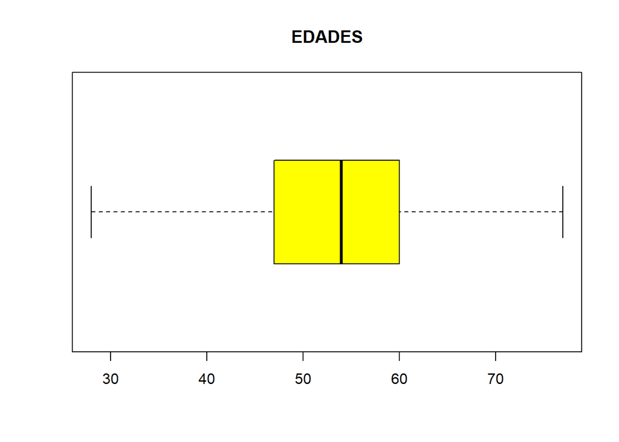

```r
boxplot(DF$Edad, horizontal=T, col="yellow", main="EDADES")
```

En este diagrama de cajas podemos ver que la mediana está centrada por lo que los datos están distribuidos casi uniformemente. Además, vemos que no hay datos atípicos, lo que es de esperarse ya que el la recolección de datos se hizo con un rango de edad definido.

### **Sexo**

```r
Nombre_datos = unique(DF$Sexo)
tabla = table(DF$Sexo)
porcentajes_sexo = prop.table(tabla)*100
sexo=table(DF$Sexo)
```

```
## [1] "Porcentaje de individuos de sexo femenino: 21.0239651416122"
```

```
## [1] "Porcentaje de individuos de sexo masculino: 78.9760348583878"
```

```
## [1] "Cantidad de individuos de sexo femenino: 193"
```

```
## [1] "Cantidad de individuos de sexo masculino: 725"
```

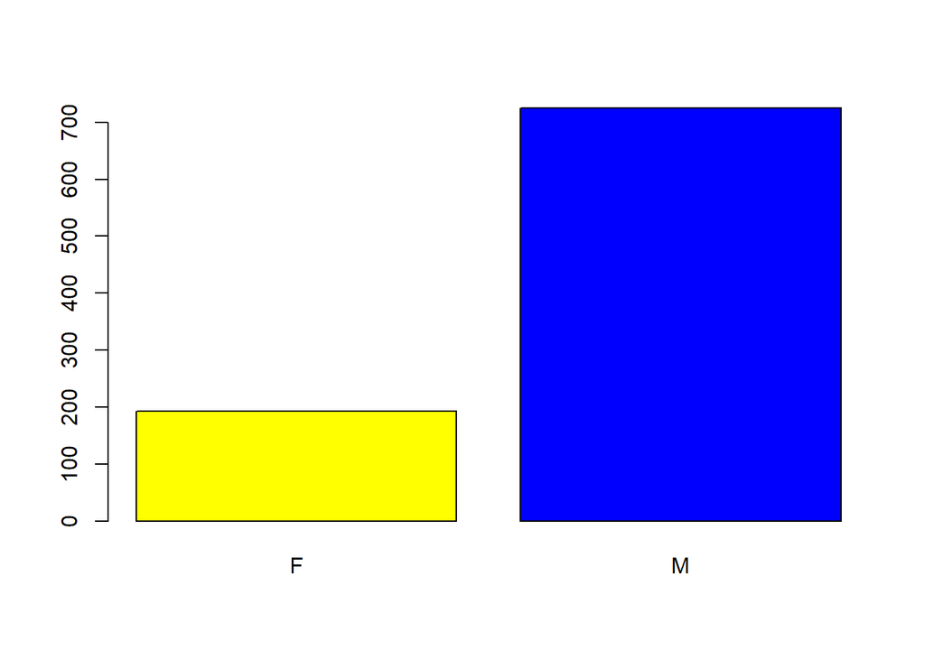

```r
barplot(sexo,col=c("yellow","blue") )
```

En este caso se utilizó una gráfica de barras porque eran variable categóricas. Podemos apreciar que la proporción de los individuos del estudio por sexo es de aproximadamente 21% para las mujeres y 79% para los hombres. Por lo que nuestro estudio será más representativo para los hombres.

### **Dolor de Pecho**

```r
Nombre_datos = unique(DF$TipoDeDolorDePecho)
tabla = table (DF$TipoDeDolorDePecho)
porcentajes_pecho = prop.table(tabla)*100
```

```
## [1] "Porcentaje de ASY: 54.0305010893246"
```

```
## [1] "Porcentaje de ATA: 18.8453159041394"
```

```
## [1] "Porcentaje de NAP: 22.1132897603486"
```

```
## [1] "Porcentaje de TA: 5.01089324618736"
```

```r
#Frecuencia del dolor de pecho
tabla_dolor = as.data.frame(table(TipoDeDolorDePecho= DF$TipoDeDolorDePecho ))
tabla_do = transform(tabla_dolor,
          FreqAc = cumsum(Freq),
          Rel = round(prop.table(Freq), 3),
          RelAc= round(cumsum(prop.table(Freq)),3))
tabla_do
```

```
##   TipoDeDolorDePecho Freq FreqAc   Rel RelAc
## 1                ASY  496    496 0.540 0.540
## 2                ATA  173    669 0.188 0.729
## 3                NAP  203    872 0.221 0.950
## 4                 TA   46    918 0.050 1.000
```

#### **Donde –>TA: angina típica, ATA: angina atípica, NAP: dolor no anginal, ASY: asintomático**

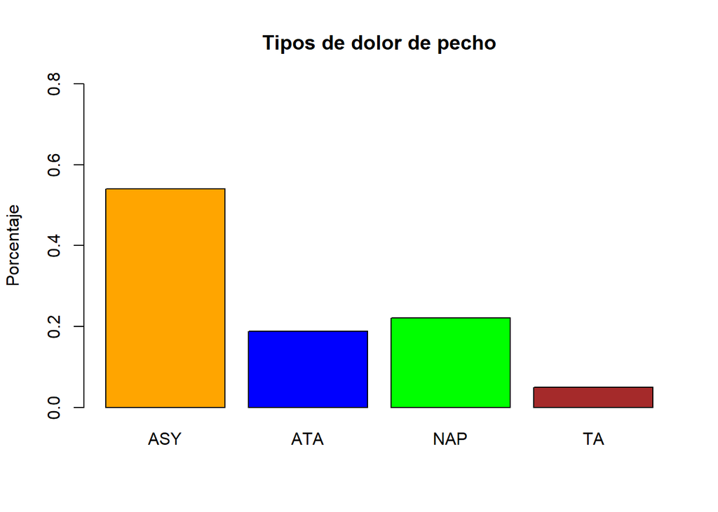

```r
barplot(prop.table(table(DF$TipoDeDolorDePecho)),col=c("orange", "blue","green", "brown"),ylim=c(0,0.8),main="Tipos de dolor de pecho", ylab ="Porcentaje")
```

En la gráfica se muestra los porcentajes de los tipos de dolor de pecho, se muestra cuatro dolores de pecho “ASY”(asintomático), “ATA”, “NAP”(dolor no angina) y “TA”(angina típica).El dolor de pecho que tiene mas frecuencia es el “ASY” , seguido por “NAP”(), “ATA” y por ultimo “TA” a través de esto podemos afirmar que el tipo de dolor de pecho “ASY” es el más común.

### **Presión arterial en reposo**

```r
maximo=max(DF$PresionArterialEnReposo)
minimo=min(DF$PresionArterialEnReposo)
media = mean(unlist(DF$PresionArterialEnReposo))
mediana = median(DF$PresionArterialEnReposo)
moda = mfv(DF$PresionArterialEnReposo)
rango= maximo-minimo
varianza = var(unlist(DF$PresionArterialEnReposo))
variación_estándar = sd(unlist(DF$PresionArterialEnReposo))
rango_intercuartil = quantile(unlist(DF$PresionArterialEnReposo), 0.75)-quantile(unlist(DF$PresionArterialEnReposo), 0.25)
```

```
## [1] "El máximo es: 200"
```

```
## [1] "El mínimo es: 0"
```

```
## [1] "La media es: 132.39651416122"
```

```
## [1] "La mediana es: 130"
```

```
## [1] "El rango es: 200"
```

```
## [1] "La varianza es: 342.773902775699"
```

```
## [1] "La variación estándar  es: 18.5141541199078"
```

```
## [1] "La rango intercuartil  es: 20"
```

```
## [1] "La moda es: 120"
```

```r
#TABLA DE PRESION ARTERIAL

tabla_edad = as.data.frame(table(Edad = DF$PresionArterialEnReposo ))
tablae = transform(tabla_edad,
          FreqAc = cumsum(Freq),
          Rel = round(prop.table(Freq), 3),
          RelAc= round(cumsum(prop.table(Freq)),3))
tablae
```

```
##    Edad Freq FreqAc   Rel RelAc
## 1     0    1      1 0.001 0.001
## 2    80    1      2 0.001 0.002
## 3    92    1      3 0.001 0.003
## 4    94    2      5 0.002 0.005
## 5    95    6     11 0.007 0.012
## 6    96    1     12 0.001 0.013
## 7    98    1     13 0.001 0.014
## 8   100   15     28 0.016 0.031
## 9   101    1     29 0.001 0.032
## 10  102    3     32 0.003 0.035
## 11  104    3     35 0.003 0.038
## 12  105    9     44 0.010 0.048
## 13  106    3     47 0.003 0.051
## 14  108    7     54 0.008 0.059
```

[output cut: 53 more lines]

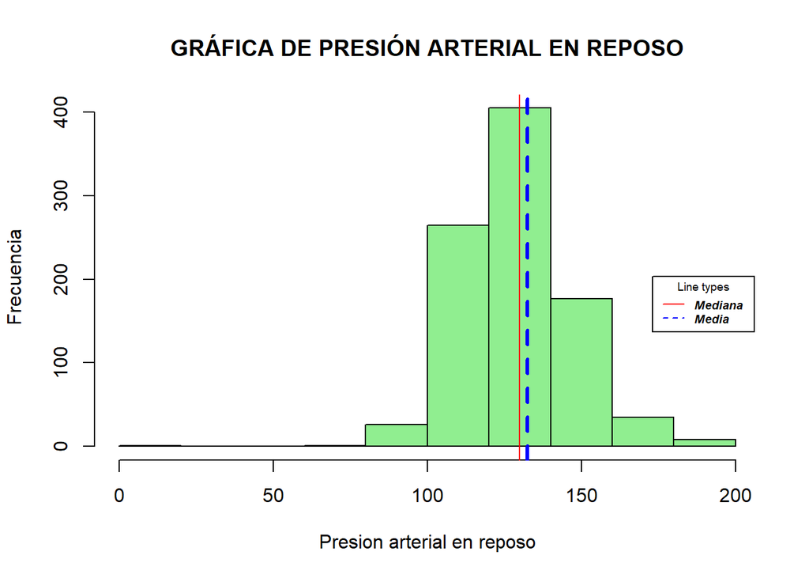

```r
#GRAFICA DE PRESIÓN ARTERIAL EN REPOSO

hist(DF$PresionArterialEnReposo,ylab="Frecuencia",col=c("lightgreen"),xlab="Presion arterial en reposo",main="GRÁFICA DE PRESIÓN ARTERIAL EN REPOSO")
abline(v = mean(DF$PresionArterialEnReposo), col="blue", lwd=3, lty=2)
abline(v = median(DF$PresionArterialEnReposo), col="red")
legend(x="bottomright", inset = c(0.009, 0.35), legend=c("Mediana  ", "Media    "),col=c("red", "blue"),lty=1:2, cex=0.6,
       title="Line types", text.font=4)
```

Al ser una variable numérica se escogió un gráfico de barras, la mayoría se encuentra en un rango de 100 y 150, se puede ver que existe poca dispersión ya que la media y mediana están juntas.

### **Colesterol Sérico**

```r
maximo=max(DF$ColesterolSerico)
minimo=min(DF$ColesterolSerico)
media = mean(unlist(DF$ColesterolSerico))
mediana = median(DF$ColesterolSerico)
moda = mfv(DF$ColesterolSerico)
rango= maximo-minimo
varianza = var(unlist(DF$ColesterolSerico))
variación_estándar = sd(unlist(DF$ColesterolSerico))
rango_intercuartil = quantile(unlist(DF$ColesterolSerico), 0.75)-quantile(unlist(DF$ColesterolSerico), 0.25)
```

```
## [1] "El máximo es: 603"
```

```
## [1] "El mínimo es: 0"
```

```
## [1] "La media es: 198.799564270153"
```

```
## [1] "La mediana es: 223"
```

```
## [1] "El rango es: 603"
```

```
## [1] "La varianza es: 11964.8910794173"
```

```
## [1] "La variación estándar  es: 109.384144552203"
```

```
## [1] "La rango intercuartil  es: 93.75"
```

```
## [1] "La moda es: 0"
```

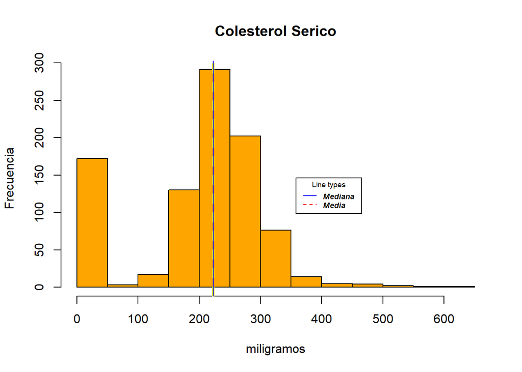

```r
hist(DF$ColesterolSerico, xlab = "miligramos", ylab = "Frecuencia"  , col = "orange",main = "Colesterol Serico")
abline(v = median(DF$ColesterolSerico), col="yellow", lwd=3, lty=2)
abline(v = median(DF$ColesterolSerico), col="blue")
legend(x="bottomright", inset = c(0.3, 0.35), legend=c("Mediana  ", "Media    "),col=c("blue", "red"),lty=1:2, cex=0.6,
       title="Line types", text.font=4)
```

#### **Diagrama de caja**

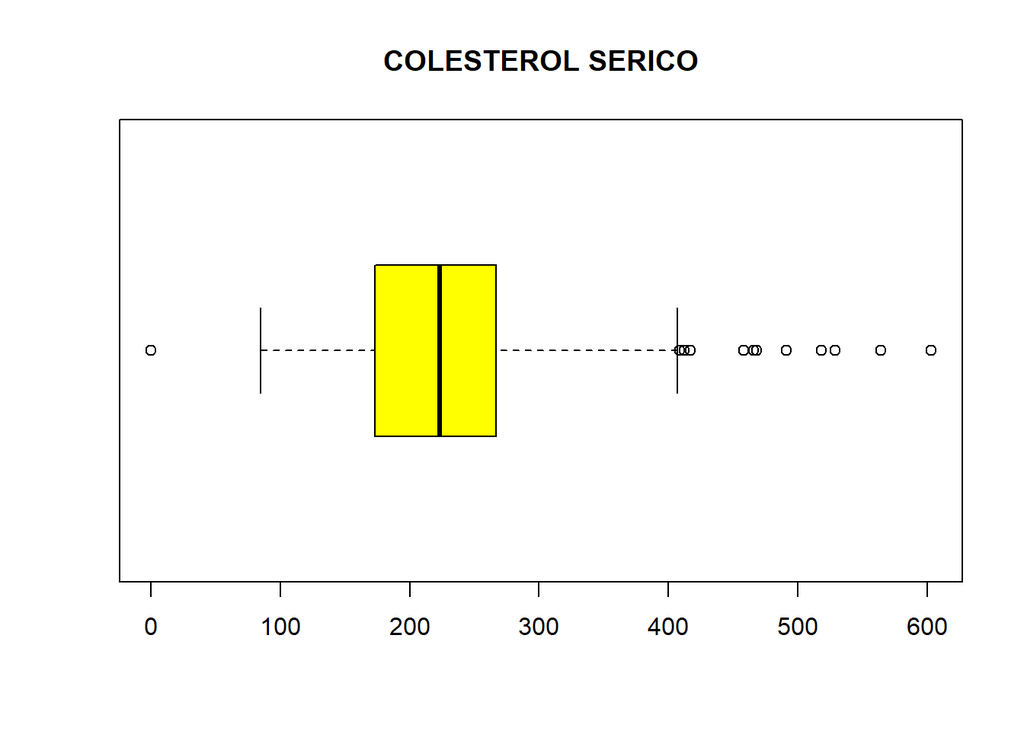

```r
boxplot(DF$ColesterolSerico, horizontal=T, col="yellow", main="COLESTEROL SERICO")
```

En este diagrama de caja podemos observar que los datos de colésterol sérico se encuentran distribuidos alrededor de la mediana, cerca a 200 miligramos/dl. Además, vemos varios datos atípicos, especialmente hacia la derecha, lo que nos indica que hay individuos que tienen el colesterol sérico muy alto, esto podría ser un factor para una enfermedad cardíaca.

### **Glucemia en Ayunas**

```r
#Porcentaje de cada dato
porcentajes_glucemia=prop.table(table(DF$GlucemiaEnAyunas))*100
moda_glucemia=mfv(DF$GlucemiaEnAyunas)
```

```
## [1] "Porcentaje de individuos con azúcar en la sangre en ayunas menor o igual a 120 mg / dl: 76.6884531590414"
```

```
## [1] "Porcentaje de individuos con azúcar en la sangre en ayunas mayor a 120 mg / dl: 23.3115468409586"
```

```
## [1] "La moda es:  0 , es decir que hay más personas con BS menor o igual a 120 mg/dl."
```

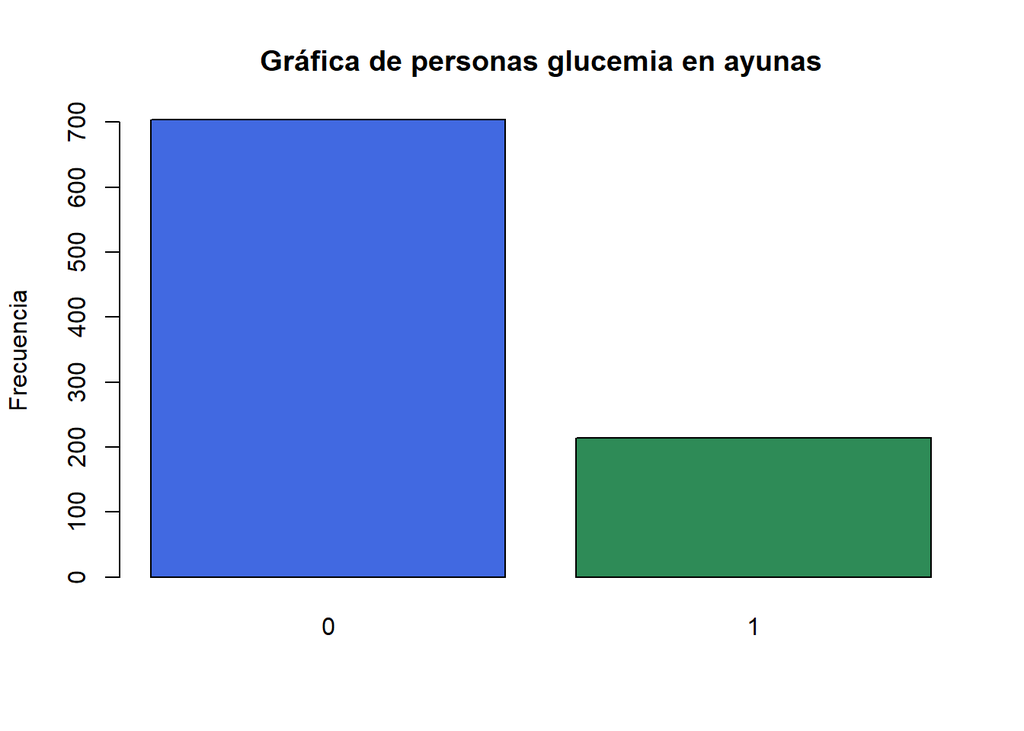

```r
barplot(table(DF$GlucemiaEnAyunas),main = "Gráfica de personas glucemia en ayunas",ylab="Frecuencia",col = c("royalblue", "seagreen"))
```

### **Resultados de Electrocardiograma en reposo**

```r
ELEC=DF$ResultadosDelElectrocardiogramaEnReposo
unique(ELEC)
```

```
## [1] "Normal" "ST"     "LVH"
```

```r
porcentajes_ELEC=prop.table(table(ELEC))*100
```

```
## [1] "La moda es: Normal"
```

```
## [1] "El porcentaje de resultado LVH en electrocardiograma en reposo es: 20.479302832244"
```

```
## [1] "El porcentaje de resultado normal en electrocardiograma en reposo es: 60.1307189542484"
```

```
## [1] "El porcentaje de resultado ST en electrocardiograma en reposo es: 19.3899782135076"
```

```r
#Frecuencia de resultados del electrocardiograma en reposo
tabla_electrocardiogama = as.data.frame(table(ResultadosDelElectrocardiogramaEnReposo= DF$ResultadosDelElectrocardiogramaEnReposo ))
tabla_e = transform(tabla_electrocardiogama,
          FreqAc = cumsum(Freq),
          Rel = round(prop.table(Freq), 3),
          RelAc= round(cumsum(prop.table(Freq)),3))
tabla_e
```

```
##   ResultadosDelElectrocardiogramaEnReposo Freq FreqAc   Rel RelAc
## 1                                     LVH  188    188 0.205 0.205
## 2                                  Normal  552    740 0.601 0.806
## 3                                      ST  178    918 0.194 1.000
```

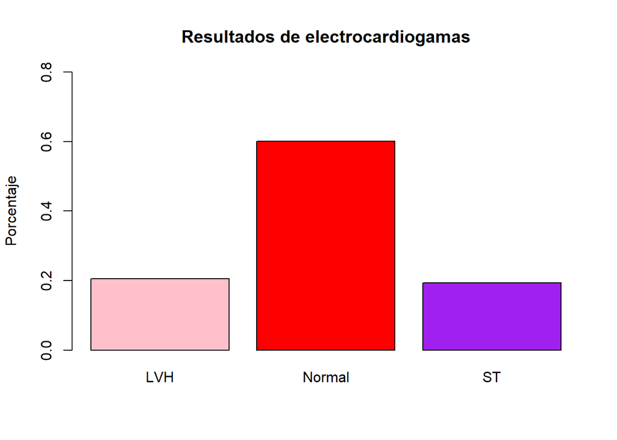

```r
barplot(prop.table(table(DF$ResultadosDelElectrocardiogramaEnReposo)),col=c("pink", "red","purple"),ylim=c(0,0.8),main="Resultados de electrocardiogamas", ylab ="Porcentaje")
```

En la gráfica se muestra los porcentajes de los resultados de los electrocardiogramas, se muestran tres el “LVH”, EL “NORMAL” y el “ST”(con anomalía de la onda), después del electrocardiograma podemos ver que el la mayoría de las personas examinadas tienen un ritmo cardíaco “NORMAL”, seguido por “LVH”y por ultimo “ST” con poca diferencia.

### **Frecuencia Cardíaca Máxima Alcanzada**

```r
FCM= DF$FrecuenciaCardiacaMaximaAlcanzada
maximo=max(FCM)
minimo=min(FCM)
#quantile(FCM, 0.5)
rango= maximo-minimo
#rango intercuartil
#quantile(FCM, 0.75)-quantile(FCM, 0.25)
rango_intercuartil=IQR(FCM)
media=mean(FCM)
varianza=var(FCM)
variación_estándar=sd(FCM)
mediana=median(FCM)
moda=mfv(FCM)
```

```
## [1] "El máximo es: 202"
```

```
## [1] "El mínimo es: 60"
```

```
## [1] "La media es: 136.809368191721"
```

```
## [1] "La mediana es: 138"
```

```
## [1] "El rango es: 142"
```

```
## [1] "La varianza es: 648.228614431354"
```

```
## [1] "La variación estándar  es: 25.4603341382503"
```

```
## [1] "La rango intercuartil  es: 36"
```

```
## [1] "La moda es: 150"
```

```r
#TABLA DE PRECUENCIA CARDIACA MÁXIMA

tabla_edad = as.data.frame(table(Edad = DF$FrecuenciaCardiacaMaximaAlcanzada ))
tablae = transform(tabla_edad,
          FreqAc = cumsum(Freq),
          Rel = round(prop.table(Freq), 3),
          RelAc= round(cumsum(prop.table(Freq)),3))
tablae
```

```
##     Edad Freq FreqAc   Rel RelAc
## 1     60    1      1 0.001 0.001
## 2     63    1      2 0.001 0.002
## 3     67    1      3 0.001 0.003
## 4     69    1      4 0.001 0.004
## 5     70    1      5 0.001 0.005
## 6     71    1      6 0.001 0.007
## 7     72    2      8 0.002 0.009
## 8     73    1      9 0.001 0.010
## 9     77    1     10 0.001 0.011
## 10    78    1     11 0.001 0.012
## 11    80    2     13 0.002 0.014
## 12    82    3     16 0.003 0.017
## 13    83    1     17 0.001 0.019
## 14    84    3     20 0.003 0.022
```

[output cut: 105 more lines]

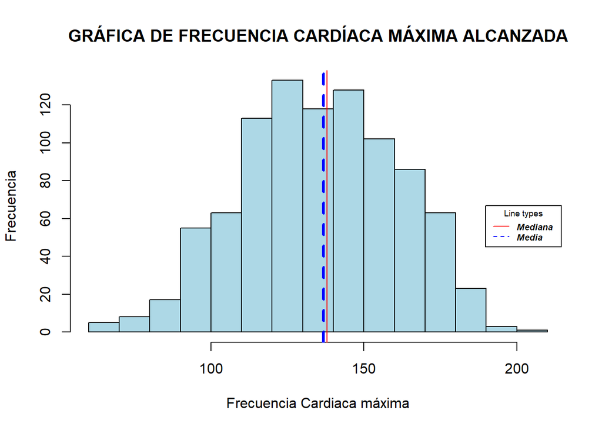

```r
#GRÁFICA DE FRECUENCIA CARDÍACA MÁXIMA ALCANZADA

hist(DF$FrecuenciaCardiacaMaximaAlcanzada,ylab="Frecuencia",col=c("lightblue"),xlab="Frecuencia Cardiaca máxima",main="GRÁFICA DE FRECUENCIA CARDÍACA MÁXIMA ALCANZADA")
abline(v = mean(DF$FrecuenciaCardiacaMaximaAlcanzada), col="blue", lwd=3, lty=2)
abline(v = median(DF$FrecuenciaCardiacaMaximaAlcanzada), col="red")
legend(x="bottomright", inset = c(0.009, 0.35), legend=c("Mediana  ", "Media    "),col=c( "red","blue"),lty=1:2, cex=0.6,
       title="Line types", text.font=4)
```

Al ser una variable numérica se debe representar mediante histogramas ya que de esta manera podemos observar su comportamiento, en este caso podemos ver que existe poca dispersión de los datos, ya que la media y mediana se encuentran cerca.

### **Angina inducida por ejercicio**

```r
ANG=DF$AnginaInducidaPorEjercicio
unique(ANG)
```

```
## [1] "N" "Y"
```

```r
porcentaje_angina=prop.table(table(ANG))*100
```

```
## [1] "Porcentaje de No (N): 59.5860566448802"
```

```
## [1] "Porcentaje de Sí (Y): 40.4139433551198"
```

```
## [1] "La moda es N"
```

```r
#Frecuencia de angina inducida por ejercicio
tabla_angina = as.data.frame(table(AnginaInducidaPorEjercicio= DF$AnginaInducidaPorEjercicio ))
tabla_a = transform(tabla_angina,
          FreqAc = cumsum(Freq),
          Rel = round(prop.table(Freq), 3),
          RelAc= round(cumsum(prop.table(Freq)),3))
tabla_a
```

```
##   AnginaInducidaPorEjercicio Freq FreqAc   Rel RelAc
## 1                          N  547    547 0.596 0.596
## 2                          Y  371    918 0.404 1.000
```

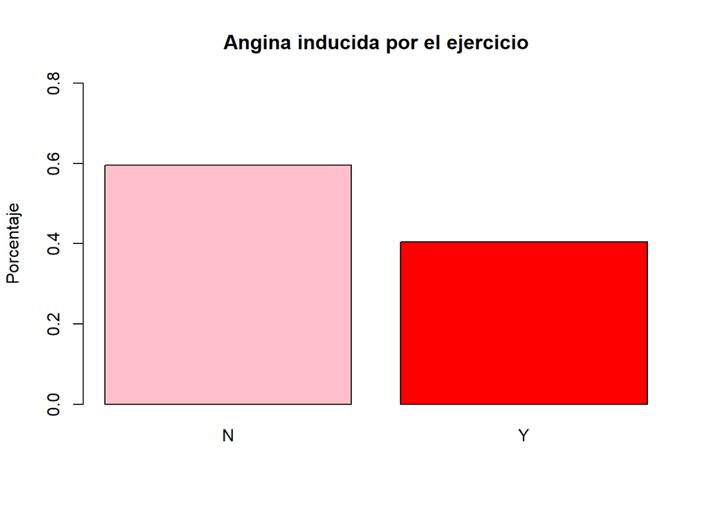

```r
barplot(prop.table(table(DF$AnginaInducidaPorEjercicio)),col=c("pink", "red","purple"),ylim=c(0,0.8),main="Angina inducida por el ejercicio", ylab ="Porcentaje")
```

En la gráfica se muestra los porcentajes de la angina inducida por el ejercicio, se muestran dos el “N” (no)y el “Y”(yes),la mayoría de las personas examinadas no tienen un angina.

### **Enfermedad Cardíaca**

```r
ENF=DF$EnfermedadCardiaca
porcentaje_heart_disease=prop.table(table(ENF))*100
enfermedad=table(DF$EnfermedadCardiaca)
```

```
## [1] "Porcentaje de No Enfermedad Cardiaca (0): 44.6623093681917"
```

```
## [1] "Porcentaje de Enfermedad Cardiaca (1): 55.3376906318083"
```

```
## [1] "Individuos sin enfermedad Cardiaca (0): 410"
```

```
## [1] "Individuos con Enfermedad Cardiaca (1): 508"
```

```
## [1] "La moda es 1"
```

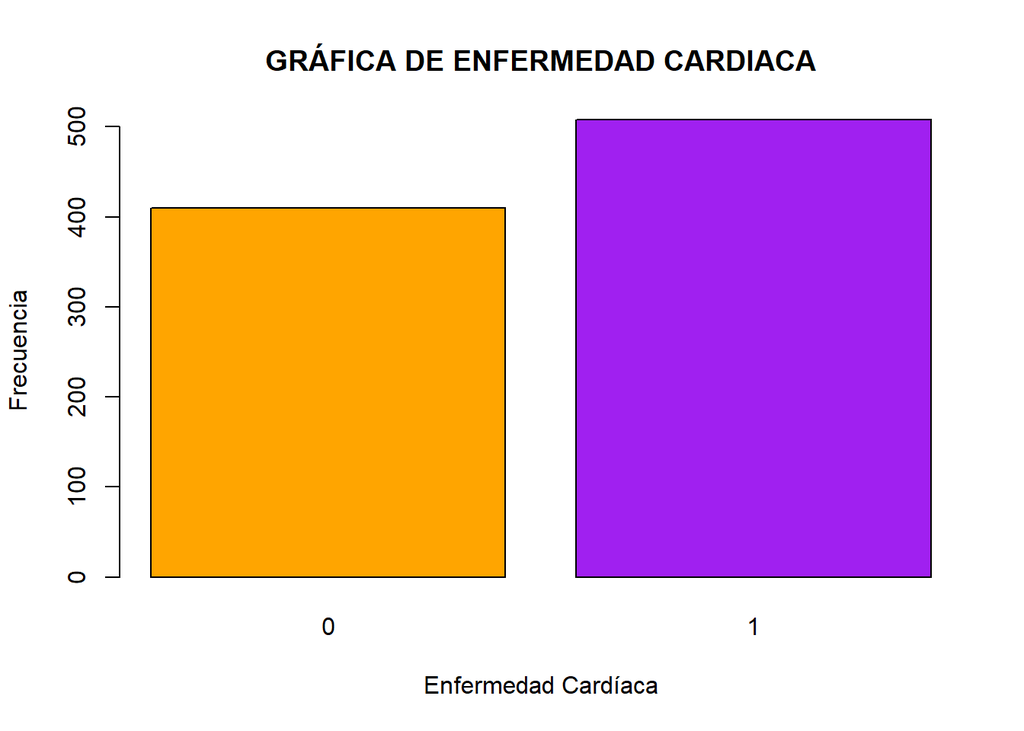

```r
barplot(table(DF$EnfermedadCardiaca), main="GRÁFICA DE ENFERMEDAD CARDIACA",ylab="Frecuencia",xlab="Enfermedad Cardíaca",col=c("orange","purple"))
```

En este caso se utilizó una gráfica de barras porque eran variable categóricas. En los individuos de nuestro estudio tenemos que 508 presentan un enfermedad cardíaca y 410 no tienen un enfermedad cardíaca.

## **Relaciones**

La siguiente gráfica compara dos variables categóricas, el sexo y la enfermedad cardíaca,en la variable de enfermedad cardíaca el valor de 0 es “No” y el de 1 es “Sí”. En este gráfico nos revela que en nuestra muestra hay más hombres que mujeres,además que las mujeres tiene pocas probabilidades a sufrir de alguna enfermedad cardíaca, a diferencia de los hombre, donde la mayoría padece de alguna enfermedad cardíaca.

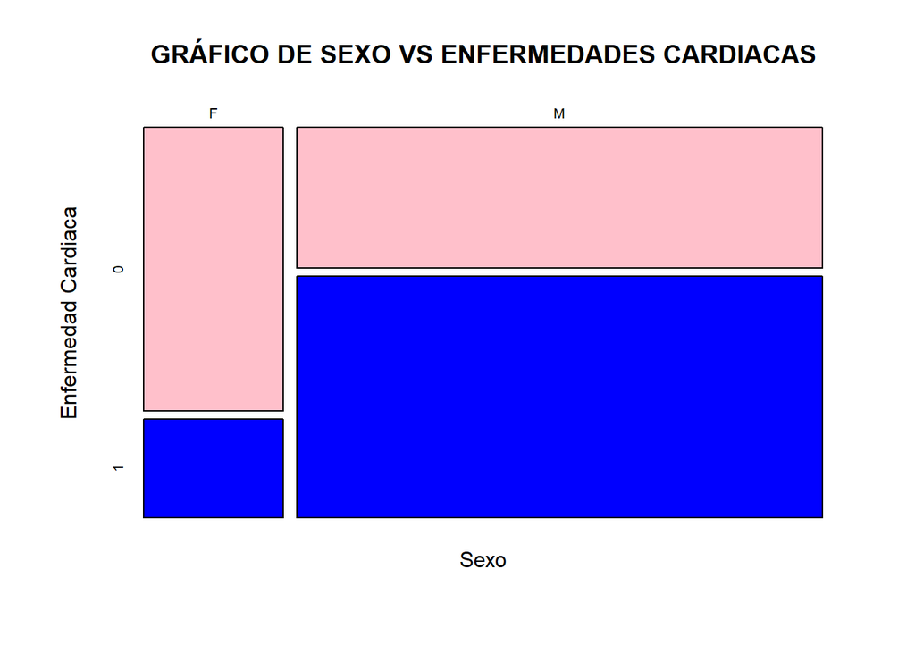

```r
#Mosaico Relación sexo-enfermedadcar

mosaicplot(table(DF$Sexo,DF$EnfermedadCardiaca),main ="GRÁFICO DE SEXO VS ENFERMEDADES CARDIACAS",xlab="Sexo",ylab="Enfermedad Cardiaca",color=c("pink", "blue"))
```

#### —————————————————————————————————–

El gráfico de mosaico nos muestra la relación de las variables de sexo y angina inducida.La variable de angina inducida se divide en “Y”(Si) “N”(No), las cuales hacen referencia a si la persona a sufrido de dolores en el pecho por el ejercicio, en donde nos damos cuenta que los hombres son más propenso a padecer estos síndromes.

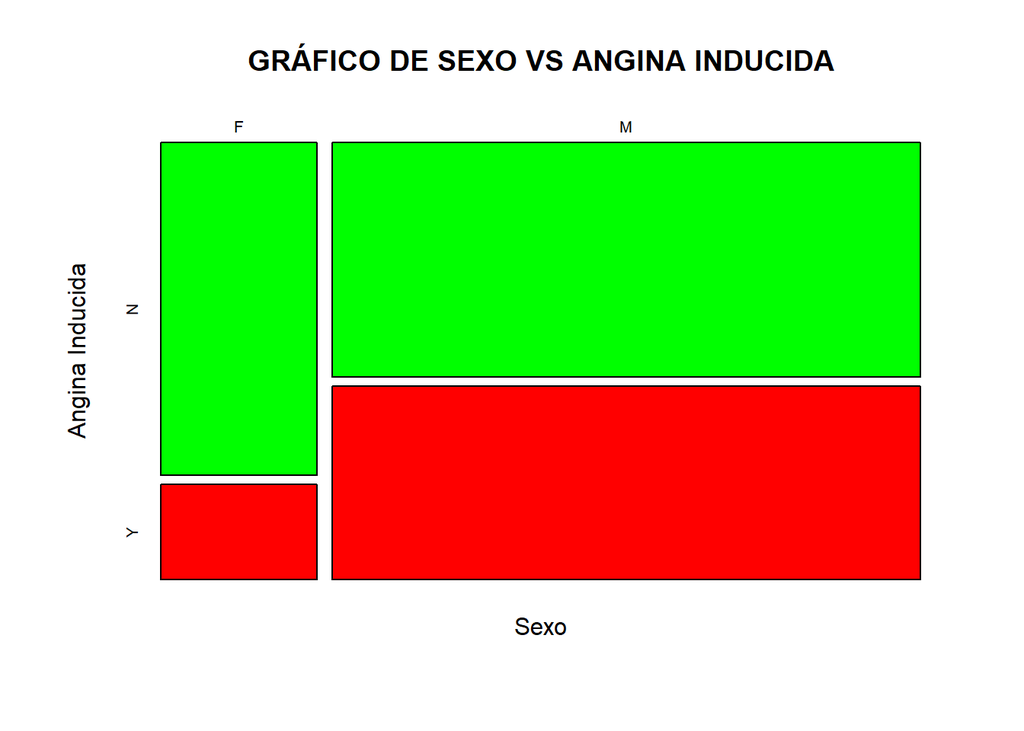

```r
#Mosaico sexo vs angina inducida

mosaicplot(table(DF$Sexo,DF$AnginaInducidaPorEjercicio),main ="GRÁFICO DE SEXO VS ANGINA INDUCIDA",xlab="Sexo",ylab="Angina Inducida",color=c("green","red"))
```

#### —————————————————————————————————–

En este caso al ser 2 variables categóricas,es preferible utilizar mosaicos para compararlos, tenemos a las variables de Glucemia en ayunas donde el “0” significa que es menos de 120 mg / dl, y 1 mayor a 120 mg / dl. Lo cual nos da a entender que mientras la glucemia sea mayor a 120 mg / dl, existirá una mayor posibilidad de sufrir de una enfermedad cardíaca. Esto podría deberse a que la glucemia es un factor importante para la diabetes, ya que los niveles altos de azúcar genera daños en las vasos sanguíneos del corazón

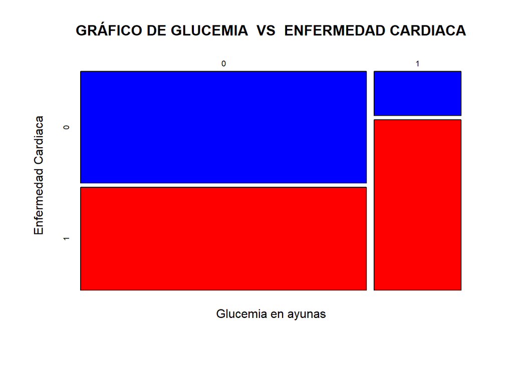

```r
#Mosaico Relacion glucemia-enfermedadcard
mosaicplot(table(DF$GlucemiaEnAyunas,DF$EnfermedadCardiaca),main="GRÁFICO DE GLUCEMIA  VS  ENFERMEDAD CARDIACA",color=c("blue", "red"),xlab="Glucemia en ayunas",ylab="Enfermedad Cardiaca")
```

#### —————————————————————————————————–

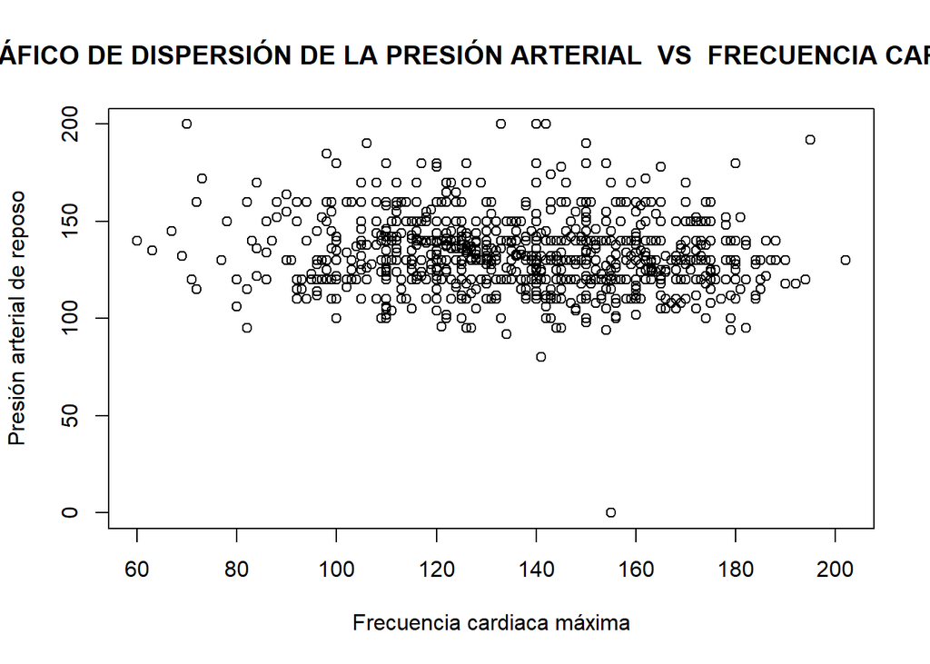

```r
#Gráfico de dispersión   frecuencia cardíaca - presionarterial
plot(DF$FrecuenciaCardiacaMaximaAlcanzada, DF$PresionArterialEnReposo,ylab="Presión arterial de reposo",xlab="Frecuencia cardiaca máxima",main="GRÁFICO DE DISPERSIÓN DE LA PRESIÓN ARTERIAL  VS  FRECUENCIA CARDIACA")
```

#### —————————————————————————————————–

La gráfica nos permite saber las relaciones que existe entre las variables del sexo y la glucemia en ayunas, las mujeres poseen una menor cantidad de glucemia mayor a 120 mg / dl, a diferencia de los hombres. Lo cual hace que en nuestra muestra los hombres sean más propensos a sufrir de diabetes.

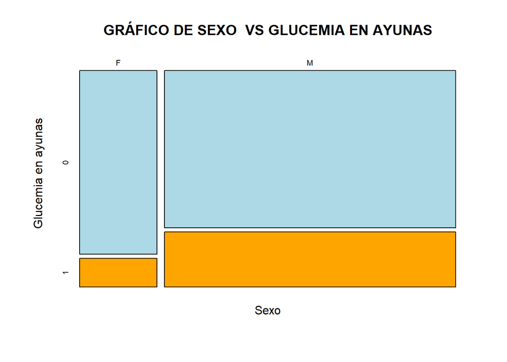

```r
#GRAFICO DE SEXO VS GLUCEMIA EN AYUNAS

mosaicplot(table(DF$Sexo,DF$GlucemiaEnAyunas),color=c("lightblue","orange"),xlab="Sexo",ylab="Glucemia en ayunas",main="GRÁFICO DE SEXO  VS GLUCEMIA EN AYUNAS")
```

#### —————————————————————————————————–

Se utiliza un gráfico de barras porque de esta manera podemos comparar una variable numérica con una variable categórica, de esta manera nos damos cuenta que las personas que tienen una mayor frecuencia cardíaca máxima son menos propensos a sufrir de alguna enfermedad cardíaca, si la frecuencia cardíaca disminuye aumentar la probabilidades de sufrir una enfermedad cardíaca.Sin embargo, es preciso recordar de que hay pocas muestras que se encuentren en los máximos y mínimos valores de frecuencia cardíaca,existe una mayor densidad en la mediana.

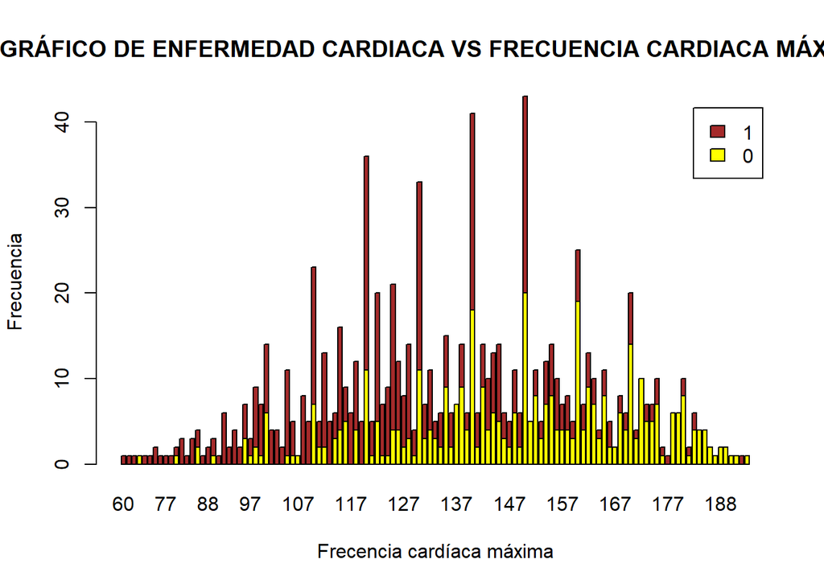

```r
#GRAFICO Enfermedadcardiaca - FrecuenciaCardiacaMaximaAlcanzada
barplot(table(DF$EnfermedadCardiaca,DF$FrecuenciaCardiacaMaximaAlcanzada),col=c("yellow","brown"),legend.text = rownames(table(DF$EnfermedadCardiaca,DF$FrecuenciaCardiacaMaximaAlcanzada)),xlab="Frecencia cardíaca máxima",ylab="Frecuencia",main="GRÁFICO DE ENFERMEDAD CARDIACA VS FRECUENCIA CARDIACA MÁXIMA")
```

#### —————————————————————————————————–

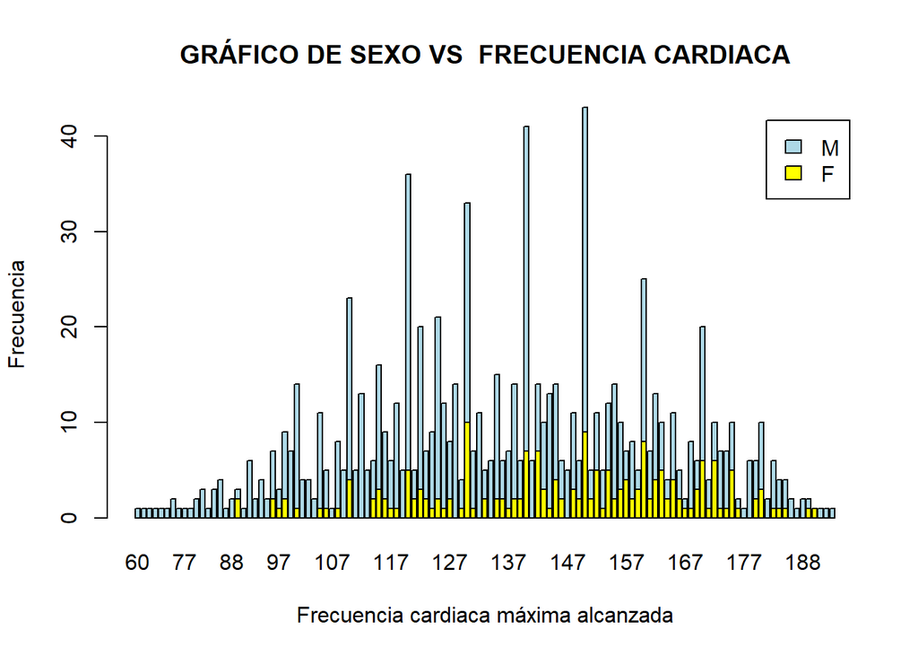

```r
#GRAFICO SEXO - FRECUENCIA CARDIACA
barplot(table(DF$Sexo,DF$FrecuenciaCardiacaMaximaAlcanzada),col=c("yellow","lightblue"),legend.text = rownames(table(DF$Sexo,DF$FrecuenciaCardiacaMaximaAlcanzada)),xlab="Frecuencia cardiaca máxima alcanzada",ylab="Frecuencia",main="GRÁFICO DE SEXO VS  FRECUENCIA CARDIACA")
```

#### **GRAFICO DE PUNTOS RELACIONANDO LA EDAD CON LOS TIPOS DE DOLOR DE PECHO, COLESTEROL SERICO,PRESIÓN ARTERIAL EN REPOSO,FRECUENCIA CARDIACA MAXIMA ALCANZADA Y ENFERMEDAD CARDIACA**

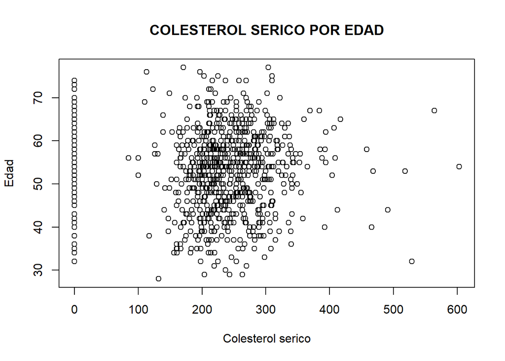

```r
plot(DF$ColesterolSerico, DF$Edad,main = "COLESTEROL SERICO POR EDAD", xlab="Colesterol serico", ylab="Edad")
```

Elegimos el gráfico de puntos para comparar las variables porque ambas son numéricas,de manera visual podemos observar mayor frecuencia de colesterol serico entre las edades de 50 a 60 años por la mayor cantidad de puntos que se observan.

#### —————————————————————————————————–

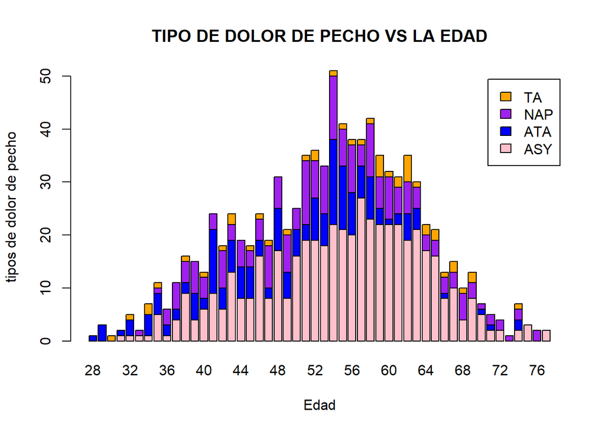

```r
barplot(table(DF$TipoDeDolorDePecho,DF$Edad),col=c("pink","blue","purple","orange"),legend.text = rownames(table(DF$TipoDeDolorDePecho,DF$Edad)),main="TIPO DE DOLOR DE PECHO VS LA EDAD", ylab="tipos de dolor de pecho", xlab="Edad")
```

Elegimos el gráfico de barras por que tenemos una variable numérica y otra variable cualitativa, de manera visual podemos observar que las personas de 55 a 58 años sufren mayor dolor de pecho y que el dolor de pecho que mas se presenta es el “ASY”(asintomático).

#### —————————————————————————————————–

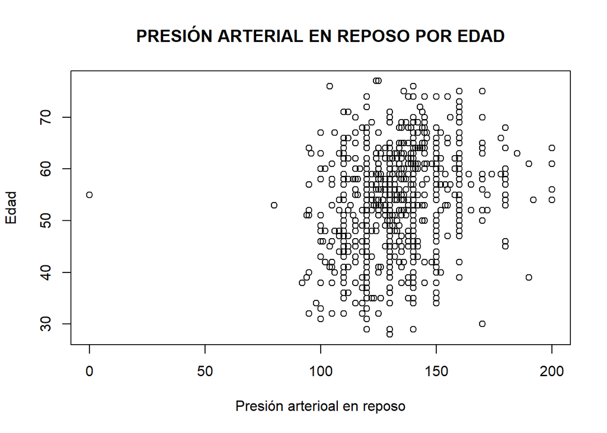

```r
plot(DF$PresionArterialEnReposo, DF$Edad,main = "PRESIÓN ARTERIAL EN REPOSO POR EDAD", xlab="Presión arterioal en reposo", ylab="Edad")
```

Elegimos el gráfico de puntos para comparar las variables porque ambas son numéricas,de manera visual podemos observar mayor frecuencia de presión arterial en reposo entre las edades de 50 a 60 años y de 100 a 140 en presión arterial por la mayor cantidad de puntos que se observan.

#### —————————————————————————————————–

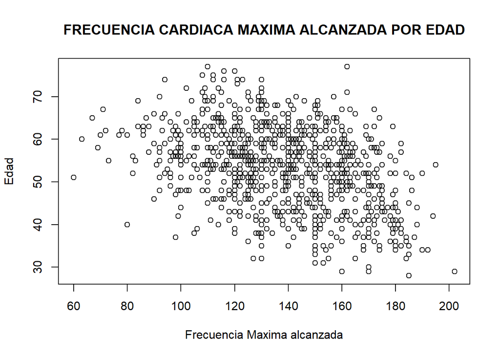

```r
plot(DF$FrecuenciaCardiacaMaximaAlcanzada, DF$Edad,main = "FRECUENCIA CARDIACA MAXIMA ALCANZADA POR EDAD", xlab="Frecuencia Maxima alcanzada", ylab="Edad")
```

Elegimos el gráfico de puntos para comparar las variables porque ambas son numéricas,de manera visual podemos observar mayor frecuencia cardíaca alcanzada entre las edades de 45 a 65 años y de 125 a 150 en la frecuencia cardíaca alcanzada más o menos por la mayor cantidad de puntos que se observan.

#### —————————————————————————————————–

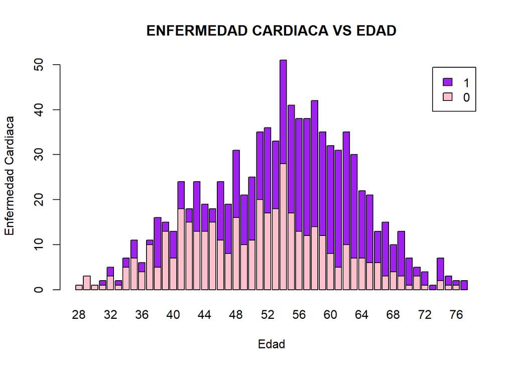

```r
barplot(table(DF$EnfermedadCardiaca,DF$Edad),col=c("pink","purple"),legend.text = rownames(table(DF$EnfermedadCardiaca,DF$Edad)),main="ENFERMEDAD CARDIACA VS EDAD", ylab="Enfermedad Cardiaca", xlab="Edad")
```

Elegimos el gráfico de barras por que tenemos una variable numérica y otra variable cualitativa, de manera visual podemos observar que las personas de 55 a 56 años sufren mayor enfermedad cardíaca y que a mayor edad es donde se presentan enfermedades cardíacas.

### **Diagramas de caja**

Se escoge esta gráfica porque es una variable numérica, porque resume la media y nos permite saber los casos atípicos. La gráfica nos muestra que en promedio la mujeres tienen una mayor media en colesterol sérico, y que los hombres poseen mayores rangos entre valores máximos y mínimos.

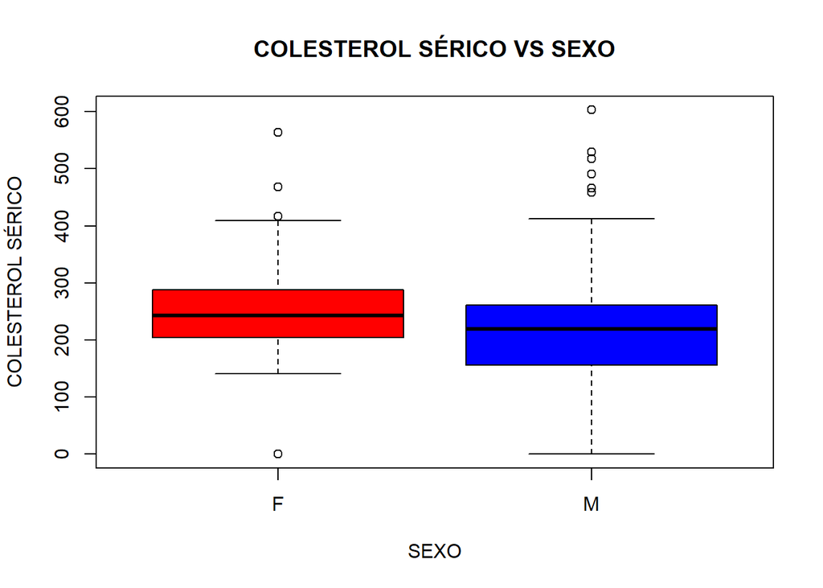

```r
boxplot(DF$ColesterolSerico~DF$Sexo, col=c("red","blue"), main="COLESTEROL SÉRICO VS SEXO", ylab="COLESTEROL SÉRICO", xlab="SEXO")
```

#### —————————————————————————————————–

En este caso la gráfica nos muestra que tanto las mujeres como los hombres tienen una media cercana, y fluctuan entre máximos y mínimos cercanos.

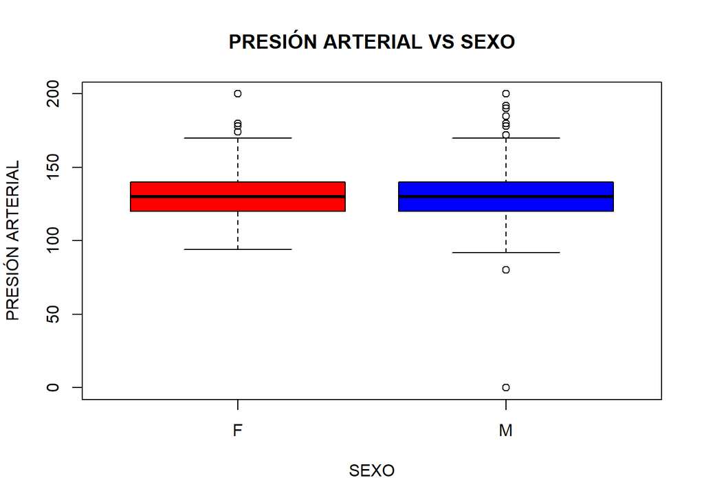

```r
boxplot(DF$PresionArterialEnReposo~DF$Sexo, col=c("red","blue"), main="PRESIÓN ARTERIAL VS SEXO", ylab="PRESIÓN ARTERIAL", xlab="SEXO")
```

#### —————————————————————————————————–

Se escoge este gráfico para poder examinar una variable numérica con una categórica, la cual nos muestra que las mujeres poseen en promedio una mayor frecuencia cardíaca máxima esto puede deberse a que usualmente las mujeres posee 10 pulsaciones más que los hombres. Sin embargo los hombres tiene mayores rangos de máximo y mínimo, lo cual puede deberse a cuestiones externas como hábitos deportivos y alimenticios.

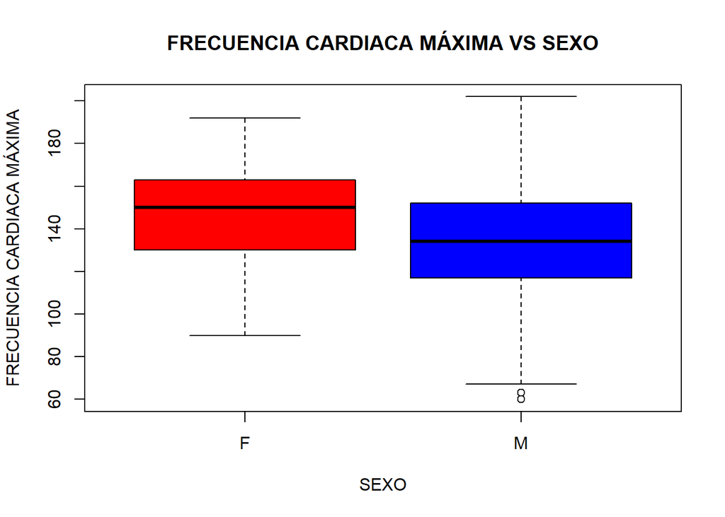

```r
boxplot(DF$FrecuenciaCardiacaMaximaAlcanzada~DF$Sexo, col=c("red","blue"), main="FRECUENCIA CARDIACA MÁXIMA VS SEXO", ylab="FRECUENCIA CARDIACA MÁXIMA", xlab="SEXO")
```

## **Modelos de variable aleatoria**

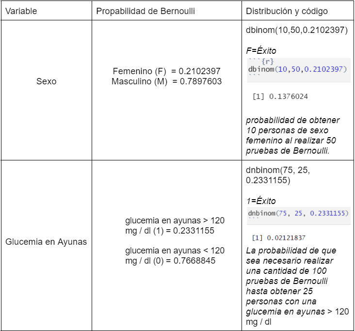

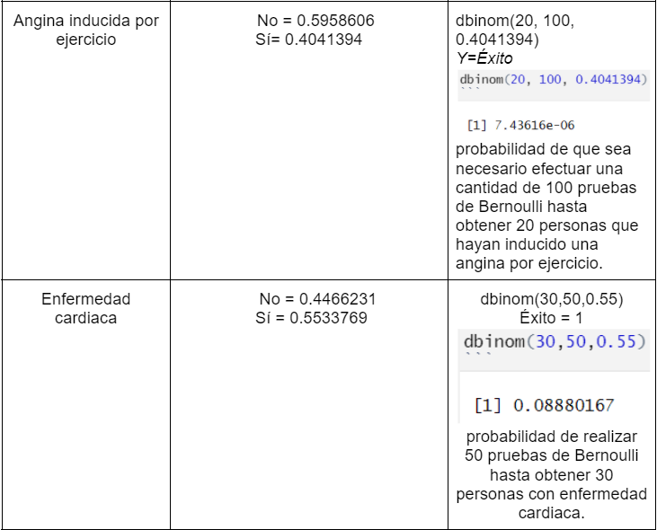

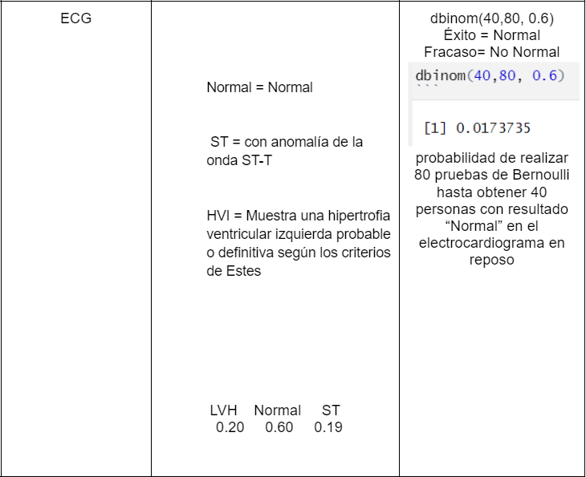

## **Patrones**

### *Patrón 1*

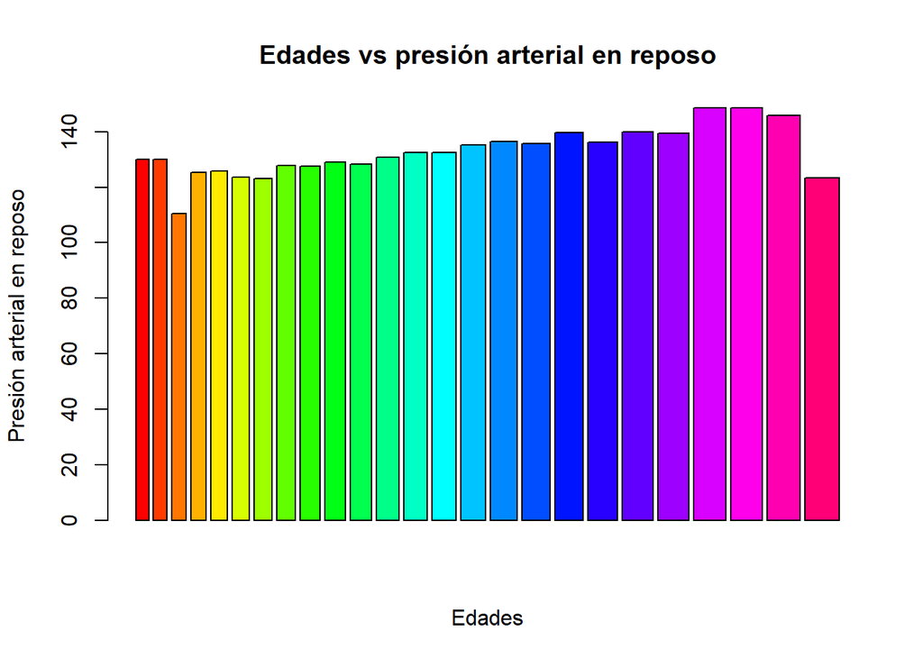

```r
  prom_P1 = mean(unlist(DF[(DF$Edad>27 & DF$Edad<=29),4]))
  prom_P2 = mean(unlist(DF[(DF$Edad>29 & DF$Edad<=31),4]))
  prom_P3 = mean(unlist(DF[(DF$Edad>31 & DF$Edad<=33),4]))
  prom_P4= mean(unlist(DF[(DF$Edad>33 & DF$Edad<=35),4]))
  prom_P5 = mean(unlist(DF[(DF$Edad>35 & DF$Edad<=37),4]))
  prom_P6 = mean(unlist(DF[(DF$Edad>37 & DF$Edad<=39),4]))
  prom_P7 = mean(unlist(DF[(DF$Edad>39 & DF$Edad<=41),4]))
  prom_P8 = mean(unlist(DF[(DF$Edad>41 & DF$Edad<=43),4]))
  prom_P9 = mean(unlist(DF[(DF$Edad>43 & DF$Edad<=45),4]))
  prom_P10 = mean(unlist(DF[(DF$Edad>45 & DF$Edad<=47),4]))
  prom_P11 = mean(unlist(DF[(DF$Edad>47 & DF$Edad<=49),4]))
  prom_P12 = mean(unlist(DF[(DF$Edad>49 & DF$Edad<=51),4]))
  prom_P13 = mean(unlist(DF[(DF$Edad>51 & DF$Edad<=53),4]))
  prom_P14= mean(unlist(DF[(DF$Edad>53 & DF$Edad<=55),4]))
  prom_P15 = mean(unlist(DF[(DF$Edad>55 & DF$Edad<=57),4]))
  prom_P16 = mean(unlist(DF[(DF$Edad>57 & DF$Edad<=59),4]))
  prom_P16 = mean(unlist(DF[(DF$Edad>59 & DF$Edad<=61),4]))
  prom_P17 = mean(unlist(DF[(DF$Edad>61 & DF$Edad<=63),4]))
  prom_P18= mean(unlist(DF[(DF$Edad>63 & DF$Edad<=65),4]))
  prom_P19 = mean(unlist(DF[(DF$Edad>65 & DF$Edad<=67),4]))
  prom_P20 = mean(unlist(DF[(DF$Edad>67 & DF$Edad<=69),4]))
  prom_P21 = mean(unlist(DF[(DF$Edad>69 & DF$Edad<=71),4]))
  prom_P22 = mean(unlist(DF[(DF$Edad>71 & DF$Edad<=73),4]))
  prom_P23= mean(unlist(DF[(DF$Edad>73 & DF$Edad<=75),4]))
  prom_P24 = mean(unlist(DF[(DF$Edad>75 & DF$Edad<=78),4]))





  prom_edad1 = mean(unlist(DF[(DF$Edad>27 & DF$Edad<=29),1]))
  prom_edad2= mean(unlist(DF[(DF$Edad>29 & DF$Edad<=31),1]))
  prom_edad3 = mean(unlist(DF[(DF$Edad>31 & DF$Edad<=33),1]))
  prom_edad4= mean(unlist(DF[(DF$Edad>33 & DF$Edad<=35),1]))
  prom_edad5 = mean(unlist(DF[(DF$Edad>35 & DF$Edad<=37),1]))
  prom_edad6 = mean(unlist(DF[(DF$Edad>37 & DF$Edad<=39),1]))
  prom_edad7 = mean(unlist(DF[(DF$Edad>39 & DF$Edad<=41),1]))
  prom_edad8 = mean(unlist(DF[(DF$Edad>41 & DF$Edad<=43),1]))
  prom_edad9 = mean(unlist(DF[(DF$Edad>43 & DF$Edad<=45),1]))
  prom_edad10 = mean(unlist(DF[(DF$Edad>45 & DF$Edad<=47),1]))
  prom_edad11 = mean(unlist(DF[(DF$Edad>47 & DF$Edad<=49),1]))
  prom_edad12 = mean(unlist(DF[(DF$Edad>49 & DF$Edad<=51),1]))
  prom_edad13 = mean(unlist(DF[(DF$Edad>51 & DF$Edad<=53),1]))
  prom_edad14= mean(unlist(DF[(DF$Edad>53 & DF$Edad<=55),1]))
  prom_edad15 = mean(unlist(DF[(DF$Edad>55 & DF$Edad<=57),1]))
  prom_edad16 = mean(unlist(DF[(DF$Edad>57 & DF$Edad<=59),1]))
  prom_edad16 = mean(unlist(DF[(DF$Edad>59 & DF$Edad<=61),1]))
  prom_edad17 = mean(unlist(DF[(DF$Edad>61 & DF$Edad<=63),1]))
  prom_edad18= mean(unlist(DF[(DF$Edad>63 & DF$Edad<=65),1]))
  prom_edad19 = mean(unlist(DF[(DF$Edad>65 & DF$Edad<=67),1]))
  prom_edad20 = mean(unlist(DF[(DF$Edad>67 & DF$Edad<=69),1]))
  prom_edad21 = mean(unlist(DF[(DF$Edad>69 & DF$Edad<=71),1]))
  prom_edad22 = mean(unlist(DF[(DF$Edad>71 & DF$Edad<=73),1]))
  prom_edad23= mean(unlist(DF[(DF$Edad>73 & DF$Edad<=75),1]))
  prom_edad24 = mean(unlist(DF[(DF$Edad>75 & DF$Edad<=78),1]))




promedios_P = data.frame(prom= c(prom_P1,prom_P2,prom_P3,prom_P4,prom_P5,prom_P6,prom_P7,prom_P8,prom_P9,prom_P10,prom_P11,prom_P12,prom_P13,prom_P14,prom_P15,prom_P16,prom_P17,prom_P18,prom_P19,prom_P20,prom_P21,prom_P22,prom_P22,prom_P23,prom_P24))

edades = data.frame(edades = c(prom_edad1,prom_edad2,prom_edad3,prom_edad4,prom_edad5,prom_edad6,prom_edad7,prom_edad8,prom_edad9,prom_edad10,prom_edad11,prom_edad12,prom_edad13,prom_edad14,prom_edad15,prom_edad16,prom_edad17,prom_edad18,prom_edad19,prom_edad20,prom_edad21,prom_edad22,prom_edad22,prom_edad23,prom_edad24))
datos<-data.frame(edades,promedios_P)


barplot(unlist(datos$prom),unlist(datos$edades),col = rainbow(26), xlab = "Edades", ylab = "Presión arterial en reposo", main = "Edades vs presión arterial en reposo")
```

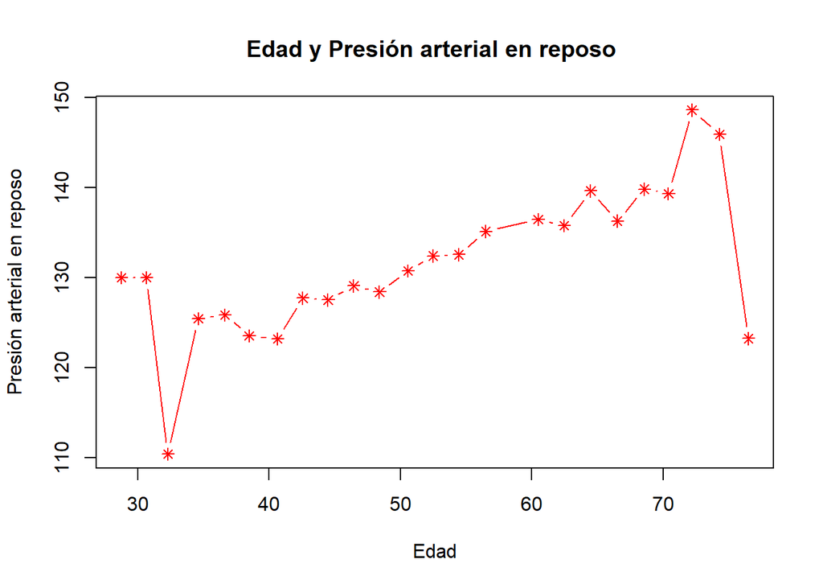

```r
plot(unlist(datos$edades),unlist(datos$prom),type = "b",main = "Edad y Presión arterial en reposo ", xlab = "Edad", ylab = "Presión arterial en reposo",pch = 8, bg = "red",  col = "red", cex = 1)
```

Estos gráficos representan la relación entre la variable edades y la variable que indica la presión arterial en reposo. Se muestra aproximadamente una relación lineal, por lo que podría indicar que a mayor edad hay una mayor presión arterial en reposo.  
Se indica que según el Ministerio de salud se considera normal en adultos una presión menor de 120 mm Hg cuando el corazón late (presión sistólica) y menor de 80 mm Hg cuando el corazón se relaja (presión diastólica). Según los datos de la muestra, se ve que hay varios casos de hipertensión y estos se hacen más graves mientras más edad se tiene.

#### —————————————————————————————————–

### *Patrón 2*

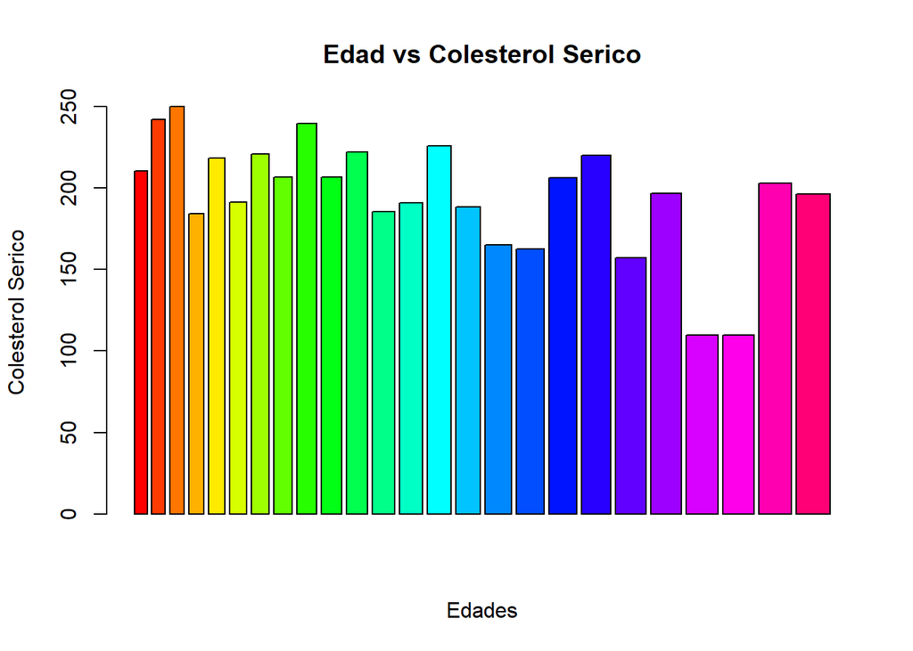

```r
  prom_C1 = mean(unlist(DF[(DF$Edad>27 & DF$Edad<=29),5]))
  prom_C2= mean(unlist(DF[(DF$Edad>29 & DF$Edad<=31),5]))
  prom_C3 = mean(unlist(DF[(DF$Edad>31 & DF$Edad<=33),5]))
  prom_C4= mean(unlist(DF[(DF$Edad>33 & DF$Edad<=35),5]))
  prom_C5 = mean(unlist(DF[(DF$Edad>35 & DF$Edad<=37),5]))
  prom_C6 = mean(unlist(DF[(DF$Edad>37 & DF$Edad<=39),5]))
  prom_C7 = mean(unlist(DF[(DF$Edad>39 & DF$Edad<=41),5]))
  prom_C8 = mean(unlist(DF[(DF$Edad>41 & DF$Edad<=43),5]))
  prom_C9 = mean(unlist(DF[(DF$Edad>43 & DF$Edad<=45),5]))
  prom_C10 = mean(unlist(DF[(DF$Edad>45 & DF$Edad<=47),5]))
  prom_C11 = mean(unlist(DF[(DF$Edad>47 & DF$Edad<=49),5]))
  prom_C12 = mean(unlist(DF[(DF$Edad>49 & DF$Edad<=51),5]))
  prom_C13 = mean(unlist(DF[(DF$Edad>51 & DF$Edad<=53),5]))
  prom_C14= mean(unlist(DF[(DF$Edad>53 & DF$Edad<=55),5]))
  prom_C15 = mean(unlist(DF[(DF$Edad>55 & DF$Edad<=57),5]))
  prom_C16 = mean(unlist(DF[(DF$Edad>57 & DF$Edad<=59),5]))
  prom_C16 = mean(unlist(DF[(DF$Edad>59 & DF$Edad<=61),5]))
  prom_C17 = mean(unlist(DF[(DF$Edad>61 & DF$Edad<=63),5]))
  prom_C18= mean(unlist(DF[(DF$Edad>63 & DF$Edad<=65),5]))
  prom_C19 = mean(unlist(DF[(DF$Edad>65 & DF$Edad<=67),5]))
  prom_C20 = mean(unlist(DF[(DF$Edad>67 & DF$Edad<=69),5]))
  prom_C21 = mean(unlist(DF[(DF$Edad>69 & DF$Edad<=71),5]))
  prom_C22 = mean(unlist(DF[(DF$Edad>71 & DF$Edad<=73),5]))
  prom_C23= mean(unlist(DF[(DF$Edad>73 & DF$Edad<=75),5]))
  prom_C24 = mean(unlist(DF[(DF$Edad>75 & DF$Edad<=78),5]))



promedios_COL = data.frame(prom= c(prom_C1,prom_C2,prom_C3,prom_C4,prom_C5,prom_C6,prom_C7,prom_C8,prom_C9,prom_C10,prom_C11,prom_C12,prom_C13,prom_C14,prom_C15,prom_C16,prom_C17,prom_C18,prom_C19,prom_C20,prom_C21,prom_C22,prom_C22,prom_C23,prom_C24))

Datos_Colesterol <- data.frame(edades,promedios_COL)

barplot(Datos_Colesterol$prom,Datos_Colesterol$edades,col = rainbow(26), main = "Edad vs Colesterol Serico", xlab = "Edades", ylab = "Colesterol Serico")
```

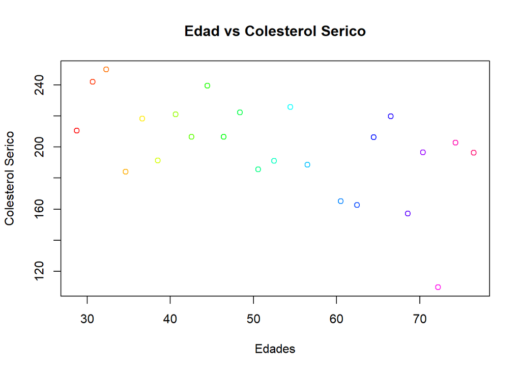

```r
plot(Datos_Colesterol$edades,Datos_Colesterol$prom,col = rainbow(26), main = "Edad vs Colesterol Serico", xlab = "Edades", ylab = "Colesterol Serico",
abline(lm(Datos_Colesterol$edades ~ Datos_Colesterol$prom),col="red"))
```

#### —————————————————————————————————–

### *Patrón 3*

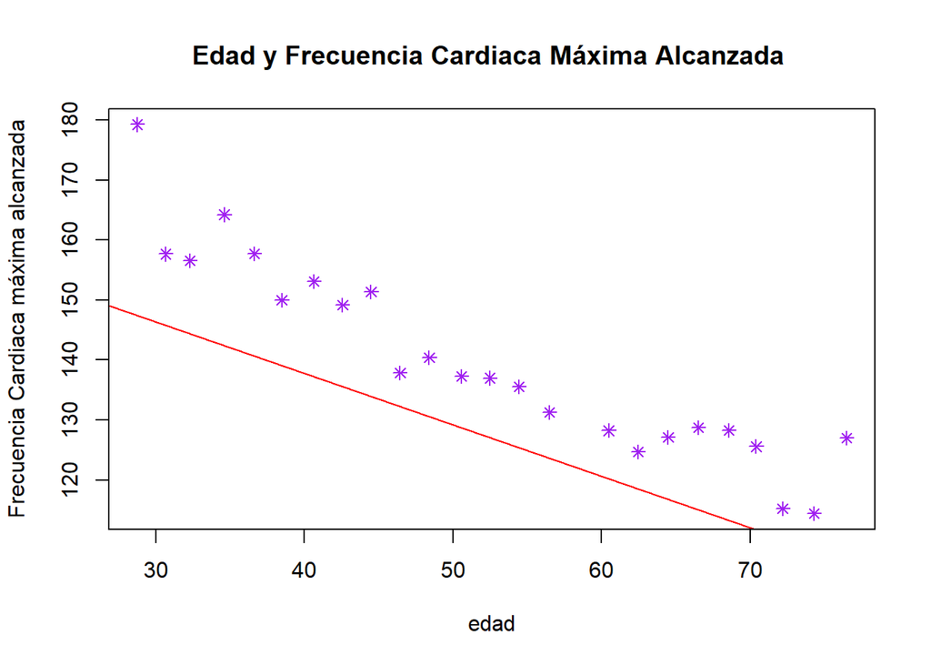

```r
  prom_F1 = mean(unlist(DF[(DF$Edad>27 & DF$Edad<=29),8]))
  prom_F2= mean(unlist(DF[(DF$Edad>29 & DF$Edad<=31),8]))
  prom_F3 = mean(unlist(DF[(DF$Edad>31 & DF$Edad<=33),8]))
  prom_F4= mean(unlist(DF[(DF$Edad>33 & DF$Edad<=35),8]))
  prom_F5 = mean(unlist(DF[(DF$Edad>35 & DF$Edad<=37),8]))
  prom_F6 = mean(unlist(DF[(DF$Edad>37 & DF$Edad<=39),8]))
  prom_F7 = mean(unlist(DF[(DF$Edad>39 & DF$Edad<=41),8]))
  prom_F8 = mean(unlist(DF[(DF$Edad>41 & DF$Edad<=43),8]))
  prom_F9 = mean(unlist(DF[(DF$Edad>43 & DF$Edad<=45),8]))
  prom_F10 = mean(unlist(DF[(DF$Edad>45 & DF$Edad<=47),8]))
  prom_F11 = mean(unlist(DF[(DF$Edad>47 & DF$Edad<=49),8]))
  prom_F12 = mean(unlist(DF[(DF$Edad>49 & DF$Edad<=51),8]))
  prom_F13 = mean(unlist(DF[(DF$Edad>51 & DF$Edad<=53),8]))
  prom_F14= mean(unlist(DF[(DF$Edad>53 & DF$Edad<=55),8]))
  prom_F15 = mean(unlist(DF[(DF$Edad>55 & DF$Edad<=57),8]))
  prom_F16 = mean(unlist(DF[(DF$Edad>57 & DF$Edad<=59),8]))
  prom_F16 = mean(unlist(DF[(DF$Edad>59 & DF$Edad<=61),8]))
  prom_F17 = mean(unlist(DF[(DF$Edad>61 & DF$Edad<=63),8]))
  prom_F18= mean(unlist(DF[(DF$Edad>63 & DF$Edad<=65),8]))
  prom_F19 = mean(unlist(DF[(DF$Edad>65 & DF$Edad<=67),8]))
  prom_F20 = mean(unlist(DF[(DF$Edad>67 & DF$Edad<=69),8]))
  prom_F21 = mean(unlist(DF[(DF$Edad>69 & DF$Edad<=71),8]))
  prom_F22 = mean(unlist(DF[(DF$Edad>71 & DF$Edad<=73),8]))
  prom_F23= mean(unlist(DF[(DF$Edad>73 & DF$Edad<=75),8]))
  prom_F24 = mean(unlist(DF[(DF$Edad>75 & DF$Edad<=78),8]))

promedios_F = data.frame(prom= c(prom_F1,prom_F2,prom_F3,prom_F4,prom_F5,prom_F6,prom_F7,prom_F8,prom_F9,prom_F10,prom_F11,prom_F12,prom_F13,prom_F14,prom_F15,prom_F16,prom_F17,prom_F18,prom_F19,prom_F20,prom_F21,prom_F22,prom_F22,prom_F23,prom_F24))

Datos_FrecuenciaMaxima <- data.frame(edades,promedios_F)

plot(unlist(Datos_FrecuenciaMaxima$edades),unlist(Datos_FrecuenciaMaxima$prom),main = "Edad y Frecuencia Cardiaca Máxima Alcanzada ", xlab = "edad", ylab = "Frecuencia Cardiaca máxima alcanzada" ,pch = 8,bg = "purple",  col = "purple", cex = 1 ,abline(lm(Datos_FrecuenciaMaxima$edades ~ Datos_FrecuenciaMaxima$prom),col="red"))
```

F(x)= -1.03x + 194.68, x e [28,78]

Esta función representa la relación entre la frecuencia cardiaca máxima alcanzada y la edad. El dominio de esta función es de 28 a 78 años que es el rango de edades de la muestra.  
Se tiene como término independiente a la edad que tiene como unidad los años y el término dependiente P qué es la frecuencia cardiaca máxima que tiene como unidad lpm.  
Según la función, hay una pendiente negativa por lo que se puede observar que la edad y la frecuencia cardiaca máxima tienen una relación inversa, lo que indicaría que mientras la edad aumenta, la frecuencia cardiaca máxima alcanzada disminuye.  
Según American heart association la relación entre la edad y la frecuencia cardiaca máxima alcanzada es inversamente proporcional. por lo que da más seguridad a la hipótesis planteada.  
https://www.goredforwomen.org/es/healthy-living/fitness/fitness-basics/target-heart-rates

```r
Datos_x <- data.frame(promedios_F,promedios_COL)
Datos_Y <- data.frame(promedios_P,promedios_F)

table(promedios_F,promedios_COL)
```

[output not shown]

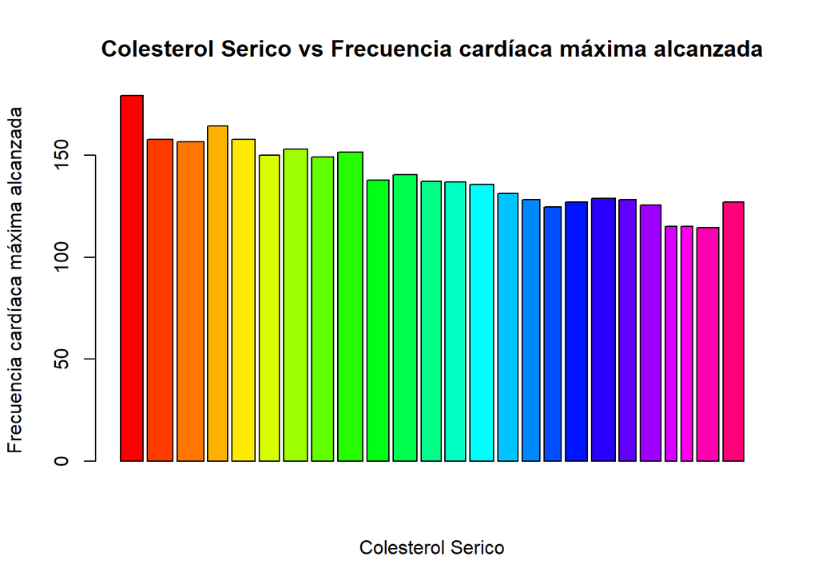

```r
barplot(Datos_x$prom,Datos_x$prom.1,col = rainbow(26), main = " Colesterol Serico vs Frecuencia cardíaca máxima alcanzada ", ylab = "Frecuencia cardíaca máxima alcanzada", xlab = "Colesterol Serico")
```

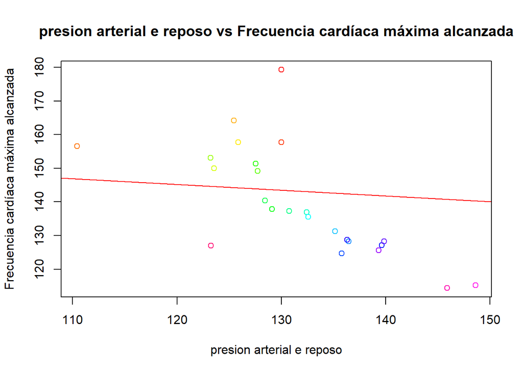

```r
plot(Datos_Y$prom,Datos_Y$prom.1,col = rainbow(26), main = " presion arterial e reposo vs Frecuencia cardíaca máxima alcanzada ", ylab = "Frecuencia cardíaca máxima alcanzada", xlab = "presion arterial e reposo",
abline(lm(Datos_Y$prom ~ Datos_x$prom.1),col="red"))
```

Esta función representa la relación entre la frecuencia cardiaca máxima alcanzada y la presión arterial en reposo. Se tiene como término independiente a la presión arterial en reposo medido en mmhg y el término dependiente P qué es la frecuencia cardiaca máxima que tiene como unidad lpm. Según la función,la frecuencia cardiaca máxima y la presión arterial tienen una relación casi lineal y que tienen mayor incidencia entre 130 mmhg y 125 a 165 lpm.

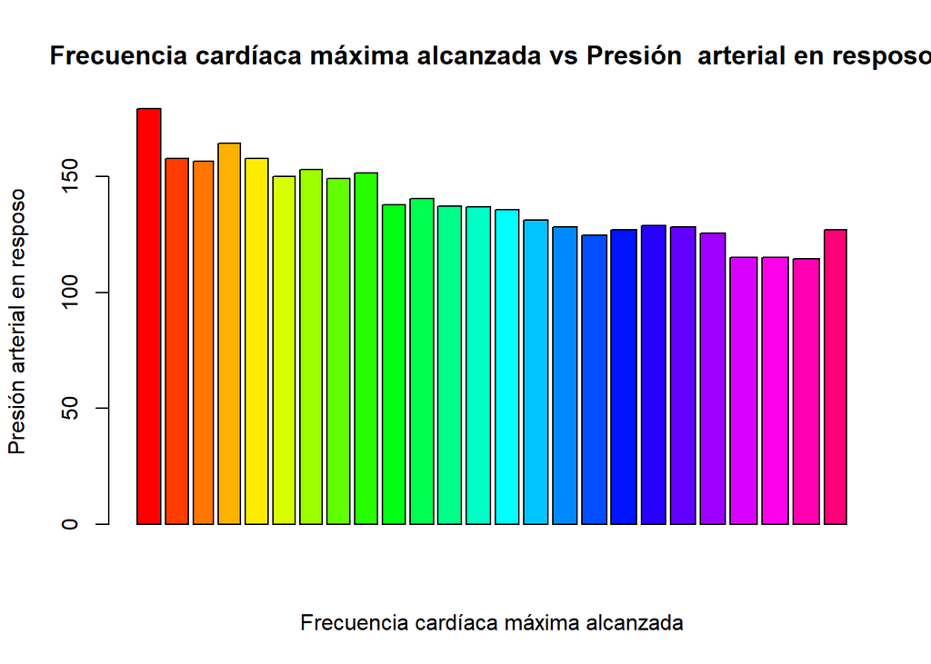

```r
barplot(Datos_Y$prom.1,Datos_Y$prom,col = rainbow(26), main = " Frecuencia cardíaca máxima alcanzada vs Presión  arterial en resposo ", xlab = "Frecuencia cardíaca máxima alcanzada", ylab = "Presión arterial en resposo ")
```